# 03_Feature_Engineering

## Notebook 03. Feature engineering and selection

### Librerias

```python
import sys
import pandas as pd
import numpy as np
import sklearn
from sklearn.pipeline import Pipeline
from sklearn import metrics
import category_encoders as ce
from sklearn.preprocessing import OneHotEncoder
from sklearn.ensemble import GradientBoostingClassifier
import matplotlib.pyplot as plt
import seaborn as sns
from sklearn.ensemble import RandomForestClassifier, AdaBoostClassifier
from sklearn.preprocessing import StandardScaler

from sklearn.metrics import classification_report, confusion_matrix, roc_curve, auc, \
                            silhouette_score, recall_score, precision_score, make_scorer, \
                            roc_auc_score, f1_score, precision_recall_curve, accuracy_score, roc_auc_score, \
                            classification_report, confusion_matrix, calinski_harabasz_score, silhouette_samples

from sklearn import metrics
from sklearn.metrics import ConfusionMatrixDisplay

from sklearn.model_selection import train_test_split
from sklearn.tree import DecisionTreeClassifier
from sklearn.linear_model import Lasso, LogisticRegression
from sklearn.feature_selection import SelectFromModel, RFE
from sklearn.manifold import TSNE
from sklearn.decomposition import PCA
from sklearn.cluster import KMeans
from sklearn.linear_model import ElasticNet
from boruta import BorutaPy
from sklearn.compose import ColumnTransformer
from sklearn.pipeline import Pipeline
from category_encoders import TargetEncoder, CatBoostEncoder
from sklearn.base import BaseEstimator, TransformerMixin
import scikitplot as skplt

import pickle
from joblib import dump, load

import warnings
warnings.filterwarnings('ignore')
```

### Funciones

```python
pd.set_option('display.max_columns', 500)
pd.set_option('display.max_rows', 10000)
pd.set_option('display.width', 10000)
```

```python
sys.path.append('../src/')
import functions as f
sys.path.remove('../src/')
```

```python
# Constants
seed= 12345
```

### Carga de dastos

```python
pd_data_train = pd.read_csv('../data/data_train_f.csv')
pd_data_test = pd.read_csv('../data/data_test_f.csv')
pd_data_train.head()
```

|  | SK_ID_CURR | COMMONAREA_AVG | NONLIVINGAPARTMENTS_AVG | FONDKAPREMONT_MODE | LIVINGAPARTMENTS_AVG | FLOORSMIN_AVG | YEARS_BUILD_AVG | OWN_CAR_AGE | LANDAREA_AVG | BASEMENTAREA_AVG | EXT_SOURCE_1 | NONLIVINGAREA_AVG | ELEVATORS_AVG | WALLSMATERIAL_MODE | APARTMENTS_AVG | ENTRANCES_AVG | LIVINGAREA_AVG | HOUSETYPE_MODE | FLOORSMAX_AVG | YEARS_BEGINEXPLUATATION_AVG | TOTALAREA_MODE | EMERGENCYSTATE_MODE | OCCUPATION_TYPE | EXT_SOURCE_3 | ORGANIZATION_TYPE | AMT_REQ_CREDIT_BUREAU_HOUR | AMT_REQ_CREDIT_BUREAU_DAY | AMT_REQ_CREDIT_BUREAU_WEEK | AMT_REQ_CREDIT_BUREAU_MON | … |
| --- | --- | --- | --- | --- | --- | --- | --- | --- | --- | --- | --- | --- | --- | --- | --- | --- | --- | --- | --- | --- | --- | --- | --- | --- | --- | --- | --- | --- | --- | --- |
| 0 | 172963 | 0.0211 | 0.0000 | Sin valor | 0.0756 | 0.2083 | 0.7552 | 16.0 | 0.0481 | 0.0763 | 0.506530 | 0.0035 | 0.00 | Sin valor | 0.0876 | 0.1379 | 0.0744 | Sin valor | 0.1667 | 0.9816 | 0.0687 | 0 | Sin valor | 0.617826 | Sin valor | 0.0 | 0.0 | 0.0 | 0.0 | … |
| 1 | 423589 | 0.0211 | 0.0000 | Sin valor | 0.0756 | 0.2083 | 0.7552 | 6.0 | 0.0481 | 0.0763 | 0.506530 | 0.0360 | 0.00 | Stone, brick | 0.1629 | 0.1034 | 0.0591 | block of flats | 0.1667 | 0.9796 | 0.0543 | 0 | Laborers | 0.502878 | Business Entity Type 1 | 0.0 | 0.0 | 0.0 | 0.0 | … |
| 2 | 392520 | 0.0693 | 0.0000 | org spec account | 0.1832 | 0.3750 | 0.8164 | 14.0 | 0.1873 | 0.1182 | 0.624748 | 0.0000 | 0.16 | Panel | 0.2247 | 0.1379 | 0.1637 | block of flats | 0.3333 | 0.9866 | 0.1288 | 0 | Sin valor | 0.493863 | Sin valor | 0.0 | 0.0 | 0.0 | 0.0 | … |
| 3 | 359127 | 0.0211 | 0.0039 | reg oper account | 0.0622 | 0.0417 | 0.9388 | 9.0 | 0.0480 | 0.1045 | 0.506530 | 0.0000 | 0.00 | Panel | 0.0773 | 0.1724 | 0.0815 | block of flats | 0.1667 | 0.9955 | 0.1055 | 0 | Managers | 0.621226 | Other | 0.0 | 0.0 | 0.0 | 0.0 | … |
| 4 | 431456 | 0.0211 | 0.0000 | Sin valor | 0.0756 | 0.2083 | 0.7552 | 9.0 | 0.0481 | 0.0763 | 0.506530 | 0.0035 | 0.00 | Sin valor | 0.0876 | 0.1379 | 0.0744 | Sin valor | 0.1667 | 0.9816 | 0.0687 | 0 | Sin valor | 0.535276 | Sin valor | 0.0 | 0.0 | 0.0 | 0.0 | … |

### Data Dictionary

```python
var_description = pd.read_excel('../data/columns_description.xlsx')
var_description.head()
```

|  | Unnamed: 0 | Table | Row | Description | Special |
| --- | --- | --- | --- | --- | --- |
| 0 | 1 | application_data | SK_ID_CURR | ID of loan in our sample | NaN |
| 1 | 2 | application_data | TARGET | Target variable (1 - client with payment diffi... | NaN |
| 2 | 5 | application_data | NAME_CONTRACT_TYPE | Identification if loan is cash or revolving | NaN |
| 3 | 6 | application_data | CODE_GENDER | Gender of the client | NaN |
| 4 | 7 | application_data | FLAG_OWN_CAR | Flag if the client owns a car | NaN |

Por no volver a repetir manualmente todos los pasos para clasificar las variables, hemos creado una función para automatizar el proceso.

```python
# We generate the lists by variable type again
pd_data_train, data_bool, data_cat, data_num = f.clas_var(pd_data_train)
```

### Distribución de la variable objetivo

```python
pd_data_train['TARGET'].value_counts()
```

```
TARGET
0    226144
1     19860
Name: count, dtype: int64
```

### **Codificación de variables categóricas**

```python
# Count unique values in each categorical variable
print(pd_data_train[data_cat].nunique())
```

```
FONDKAPREMONT_MODE              5
WALLSMATERIAL_MODE              8
HOUSETYPE_MODE                  4
OCCUPATION_TYPE                19
ORGANIZATION_TYPE              58
NAME_TYPE_SUITE                 8
REGION_RATING_CLIENT_W_CITY     3
WEEKDAY_APPR_PROCESS_START      7
NAME_INCOME_TYPE                8
REGION_RATING_CLIENT            3
NAME_HOUSING_TYPE               6
NAME_FAMILY_STATUS              6
NAME_EDUCATION_TYPE             5
NAME_CONTRACT_TYPE              2
dtype: int64
```

Después de observar el número de valores únicos que presentan nuestras variables categóricas. Establecemos los siguientes criterios de encoding:

- $\leq$ 4 categorías: One-Hot Encoding.
- 5-20 categorías: Target Encoding o Ordinal Encoding (si existe un orden implícito). Este tipo de encoding se lo aplicaremos únicamente a NAME_EDUCATION_TYPE.
- $>$ 20 categorías: Mean Encoding o CatBoost Encoding, para reducir dimensionalidad y evitar overfitting. Vamos a utilizar CatBoost Encoding.

#### Separación en X e y

```python
y_train = pd_data_train['TARGET']
X_train = pd_data_train.drop('TARGET', axis=1)
y_test = pd_data_test['TARGET']
X_test = pd_data_test.drop('TARGET', axis=1)

X_train.shape, y_train.shape, X_test.shape, y_test.shape
```

```
((246004, 93), (246004,), (61503, 93), (61503,))
```

### One-Hot Encoding

Vamos a codificar de forma manual la variable *NAME_CONTRACT_TYPE*, cambiándola a tipo booleano, ya que sólo tiene dos valores.

```python
X_train['NAME_CONTRACT_TYPE'] = X_train['NAME_CONTRACT_TYPE'].apply(lambda x: 1 if x == 'Revolving loans' else 0)
X_test['NAME_CONTRACT_TYPE'] = X_test['NAME_CONTRACT_TYPE'].apply(lambda x: 1 if x == 'Revolving loans' else 0)
```

```python
data_bool.append('NAME_CONTRACT_TYPE')
data_cat.remove('NAME_CONTRACT_TYPE')
```

```python
# choose colums one-hot encoding can be applied to
ohe_data_cat = [x for x in data_cat if pd_data_train[x].nunique() <= 4]
print(ohe_data_cat)
```

```
['HOUSETYPE_MODE', 'REGION_RATING_CLIENT_W_CITY', 'REGION_RATING_CLIENT']
```

Como REGION_RATING_CLIENT_W_CITY y REGION_RATING_CLIENT ya tienen valores [1,2,3], no vemos necesario aplicarles otra codificación.

```python
# create and apply one-hot encoder
ohe = ce.OneHotEncoder(cols='HOUSETYPE_MODE', use_cat_names=True)
ohe.fit(X_train, y_train)

# transform data
X_train_t = ohe.transform(X_train)
X_test_t = ohe.transform(X_test)

print(X_train_t.shape, X_test_t.shape)
```

```
(246004, 96) (61503, 96)
```

### Ordinal Encoding

Vamos a hacerlo manualmente, para poder asignar un orden intuitivo de menor a mayor nivel de educación. El orden que consideramos es el siguiente:

1. Lower secondary
2. Secondary / secondary special
3. Incomplete higher
4. Higher education
5. Academic degree

```python
education_mapping = {
    'Lower secondary': 1 ,
    'Secondary / secondary special': 2 ,
    'Incomplete higher': 3 ,
    'Higher education': 4 ,
    'Academic degree': 5
}

# Replace the values in the 'education' column
X_train_t['NAME_EDUCATION_TYPE'] = X_train_t['NAME_EDUCATION_TYPE'].replace(education_mapping)
X_test_t['NAME_EDUCATION_TYPE'] = X_test_t['NAME_EDUCATION_TYPE'].replace(education_mapping)
```

### Target Encoding

```python
data_cat.remove('HOUSETYPE_MODE')
```

```python
# Select columns for target encoding
te_data_cat = [x for x in data_cat
                    if 5 <= X_train_t[x].nunique() < 20]
te_data_cat
```

```
['FONDKAPREMONT_MODE',
 'WALLSMATERIAL_MODE',
 'OCCUPATION_TYPE',
 'NAME_TYPE_SUITE',
 'WEEKDAY_APPR_PROCESS_START',
 'NAME_INCOME_TYPE',
 'NAME_HOUSING_TYPE',
 'NAME_FAMILY_STATUS',
 'NAME_EDUCATION_TYPE']
```

```python
# Create and apply target encoder
target_enc = ce.TargetEncoder(cols=te_data_cat)
target_enc.fit(X_train_t[te_data_cat], y_train)

# Transform the data
X_train_s = X_train_t.copy()
X_test_s = X_test_t.copy()

X_train_s[te_data_cat] = target_enc.transform(X_train_t[te_data_cat])
X_test_s[te_data_cat] = target_enc.transform(X_test_t[te_data_cat])

# Verificar formas finales
print(X_train_s.shape, X_test_s.shape)
```

```
(246004, 96) (61503, 96)
```

### CatBoost Encoding

```python
# Create and apply catboost encoder
catboost_enc = ce.CatBoostEncoder(cols=['ORGANIZATION_TYPE'])
catboost_enc.fit(X_train_s['ORGANIZATION_TYPE'], y_train)

# Transform the data
X_train_f = X_train_s.copy()
X_test_f = X_test_s.copy()

X_train_f['ORGANIZATION_TYPE'] = catboost_enc.transform(X_train_s['ORGANIZATION_TYPE'])
X_test_f['ORGANIZATION_TYPE'] = catboost_enc.transform(X_test_s['ORGANIZATION_TYPE'])

print(X_train_f.shape, X_test_f.shape)
```

```
(246004, 96) (61503, 96)
```

```python
X_train_f.head()
```

|  | SK_ID_CURR | COMMONAREA_AVG | NONLIVINGAPARTMENTS_AVG | FONDKAPREMONT_MODE | LIVINGAPARTMENTS_AVG | FLOORSMIN_AVG | YEARS_BUILD_AVG | OWN_CAR_AGE | LANDAREA_AVG | BASEMENTAREA_AVG | EXT_SOURCE_1 | NONLIVINGAREA_AVG | ELEVATORS_AVG | WALLSMATERIAL_MODE | APARTMENTS_AVG | ENTRANCES_AVG | LIVINGAREA_AVG | HOUSETYPE_MODE_Sin valor | HOUSETYPE_MODE_block of flats | HOUSETYPE_MODE_specific housing | HOUSETYPE_MODE_terraced house | FLOORSMAX_AVG | YEARS_BEGINEXPLUATATION_AVG | TOTALAREA_MODE | EMERGENCYSTATE_MODE | OCCUPATION_TYPE | EXT_SOURCE_3 | ORGANIZATION_TYPE | AMT_REQ_CREDIT_BUREAU_HOUR | … |
| --- | --- | --- | --- | --- | --- | --- | --- | --- | --- | --- | --- | --- | --- | --- | --- | --- | --- | --- | --- | --- | --- | --- | --- | --- | --- | --- | --- | --- | --- | --- |
| 0 | 172963.0 | 0.0211 | 0.0000 | 0.086208 | 0.0756 | 0.2083 | 0.7552 | 16.0 | 0.0481 | 0.0763 | 0.506530 | 0.0035 | 0.00 | 0.091636 | 0.0876 | 0.1379 | 0.0744 | 1 | 0 | 0 | 0 | 0.1667 | 0.9816 | 0.0687 | 0 | 0.065155 | 0.617826 | 0.054791 | 0.0 | … |
| 1 | 423589.0 | 0.0211 | 0.0000 | 0.086208 | 0.0756 | 0.2083 | 0.7552 | 6.0 | 0.0481 | 0.0763 | 0.506530 | 0.0360 | 0.00 | 0.073945 | 0.1629 | 0.1034 | 0.0591 | 0 | 1 | 0 | 0 | 0.1667 | 0.9796 | 0.0543 | 0 | 0.105720 | 0.502878 | 0.081121 | 0.0 | … |
| 2 | 392520.0 | 0.0693 | 0.0000 | 0.059951 | 0.1832 | 0.3750 | 0.8164 | 14.0 | 0.1873 | 0.1182 | 0.624748 | 0.0000 | 0.16 | 0.063740 | 0.2247 | 0.1379 | 0.1637 | 0 | 1 | 0 | 0 | 0.3333 | 0.9866 | 0.1288 | 0 | 0.065155 | 0.493863 | 0.054791 | 0.0 | … |
| 3 | 359127.0 | 0.0211 | 0.0039 | 0.069806 | 0.0622 | 0.0417 | 0.9388 | 9.0 | 0.0480 | 0.1045 | 0.506530 | 0.0000 | 0.00 | 0.063740 | 0.0773 | 0.1724 | 0.0815 | 0 | 1 | 0 | 0 | 0.1667 | 0.9955 | 0.1055 | 0 | 0.062960 | 0.621226 | 0.078670 | 0.0 | … |
| 4 | 431456.0 | 0.0211 | 0.0000 | 0.086208 | 0.0756 | 0.2083 | 0.7552 | 9.0 | 0.0481 | 0.0763 | 0.506530 | 0.0035 | 0.00 | 0.091636 | 0.0876 | 0.1379 | 0.0744 | 1 | 0 | 0 | 0 | 0.1667 | 0.9816 | 0.0687 | 0 | 0.065155 | 0.535276 | 0.054791 | 0.0 | … |

Después de aplicar los encodings tenemos 96 columnas todas numéricas con 246004 registros para cada columna. Los datos están listos para hacer el escalado.

## **Escalado de variables**

El escalado es el proceso de normalizar los datos, para que tomen valores de una distribución normal con media 0 y desviación típica 1: $\mathcal{N}(0,1)$.

```python
scaler = StandardScaler()
model_scaled = scaler.fit(X_train_f)
X_train_scaled = pd.DataFrame(scaler.transform(X_train_f), columns=X_train_f.columns, index=X_train_f.index)
X_test_scaled = pd.DataFrame(scaler.transform(X_test_f), columns=X_test_f.columns, index=X_test_f.index)
```

```python
X_train_scaled.head()
```

|  | SK_ID_CURR | COMMONAREA_AVG | NONLIVINGAPARTMENTS_AVG | FONDKAPREMONT_MODE | LIVINGAPARTMENTS_AVG | FLOORSMIN_AVG | YEARS_BUILD_AVG | OWN_CAR_AGE | LANDAREA_AVG | BASEMENTAREA_AVG | EXT_SOURCE_1 | NONLIVINGAREA_AVG | ELEVATORS_AVG | WALLSMATERIAL_MODE | APARTMENTS_AVG | ENTRANCES_AVG | LIVINGAREA_AVG | HOUSETYPE_MODE_Sin valor | HOUSETYPE_MODE_block of flats | HOUSETYPE_MODE_specific housing | HOUSETYPE_MODE_terraced house | FLOORSMAX_AVG | YEARS_BEGINEXPLUATATION_AVG | TOTALAREA_MODE | EMERGENCYSTATE_MODE | OCCUPATION_TYPE | EXT_SOURCE_3 | ORGANIZATION_TYPE | AMT_REQ_CREDIT_BUREAU_HOUR | … |
| --- | --- | --- | --- | --- | --- | --- | --- | --- | --- | --- | --- | --- | --- | --- | --- | --- | --- | --- | --- | --- | --- | --- | --- | --- | --- | --- | --- | --- | --- | --- |
| 0 | -1.024214 | -0.164997 | -0.100882 | 0.668699 | -0.149723 | -0.082050 | 0.014299 | 0.834502 | -0.141168 | -0.094357 | 0.013131 | -0.231761 | -0.369027 | 0.895244 | -0.189592 | -0.082746 | -0.206095 | 0.998432 | -0.980802 | -0.070013 | -0.063598 | -0.280469 | 0.047275 | -0.221180 | -0.08792 | -0.715761 | 0.584421 | -1.338833 | -0.071577 | … |
| 1 | 1.414688 | -0.164997 | -0.100882 | 0.668699 | -0.149723 | -0.082050 | 0.014299 | -0.567532 | -0.141168 | -0.094357 | 0.013131 | 0.445617 | -0.369027 | -0.557011 | 0.785491 | -0.570789 | -0.398529 | -1.001570 | 1.019573 | -0.070013 | -0.063598 | -0.280469 | 0.000636 | -0.403764 | -0.08792 | 1.148382 | -0.073356 | 0.020141 | -0.071577 | … |
| 2 | 1.112348 | 0.955786 | -0.100882 | -2.536951 | 1.868214 | 1.726154 | 0.948106 | 0.554095 | 2.501986 | 0.691546 | 0.860588 | -0.304709 | 1.229446 | -1.394681 | 1.585759 | -0.082746 | 0.917064 | -1.001570 | 1.019573 | -0.070013 | -0.063598 | 1.279556 | 0.163871 | 0.540856 | -0.08792 | -0.715761 | -0.124946 | -1.338833 | -0.071577 | … |
| 3 | 0.787392 | -0.164997 | 0.045203 | -1.333813 | -0.401027 | -1.889170 | 2.815720 | -0.146922 | -0.143067 | 0.434580 | 0.013131 | -0.304709 | -0.369027 | -1.394681 | -0.322970 | 0.405298 | -0.116796 | -1.001570 | 1.019573 | -0.070013 | -0.063598 | -0.280469 | 0.371412 | 0.245425 | -0.08792 | -0.816636 | 0.603878 | -0.106383 | -0.071577 | … |
| 4 | 1.491243 | -0.164997 | -0.100882 | 0.668699 | -0.149723 | -0.082050 | 0.014299 | -0.146922 | -0.141168 | -0.094357 | 0.013131 | -0.231761 | -0.369027 | 0.895244 | -0.189592 | -0.082746 | -0.206095 | 0.998432 | -0.980802 | -0.070013 | -0.063598 | -0.280469 | 0.047275 | -0.221180 | -0.08792 | -0.715761 | 0.112038 | -1.338833 | -0.071577 | … |

## **Reducción de dimensionalidad**

En este proyecto, decidimos probar varias técnicas de reducción de dimensionalidad para simplificar los datos, manteniendo la mayor parte de la información relevante. Esto facilita tanto la visualización como la interpretación de los datos, sino que también puede mejora la eficiencia de los modelos al reducir la complejidad. Aunque estas técnicas son útiles, algunas pueden no ser las más apropiadas dependiendo del tipo de análisis, especialmente cuando se trabaja con grandes conjuntos de datos debido a sus altos costos computacionales. A continuación, presentamos las técnicas que utilizamos: **T-SNE**, **PCA** y **K-means**.

- **T-SNE** (t-Distributed Stochastic Neighbor Embedding) : se utiliza principalmente para visualizar datos complejos en espacios de menor dimensión, normalmente 2D o 3D. Esta técnica es especialmente útil cuando se trata de datos de alta dimensión, ya que intenta preservar la proximidad de los puntos en el espacio original, mostrándolos en un espacio reducido de tal manera que los puntos que están cerca en el espacio original sigan estando cerca en el espacio reducido. Esto ayuda a ver la estructura local de los datos.
- **PCA** (Análisis de Componentes Principales) : es una técnica de reducción de dimensionalidad lineal. PCA es una técnica más simple de reducción de dimensionalidad que transforma las variables originales en nuevos componentes no correlacionados. Cada componente es una combinación lineal de las variables originales y se ordena de tal manera que las primeras componentes explican la mayor parte de la variabilidad de los datos. Al hacer esto, podemos reducir el número de variables sin perder demasiada información, lo que ayuda a que el modelo sea más eficiente y evita el sobreajuste. Es una de las técnicas más comunes y útiles cuando se trabaja con datos que tienen muchas características.
- **K-means** (Agrupamiento no supervisado) : es una técnica de agrupamiento que organiza los datos en clusters según sus similitudes. Aunque se utiliza principalmente como un algoritmo de clasificación, K-means también puede ser útil para reducir la dimensionalidad, ya que agrupa los datos en un número reducido de clusters, lo que puede facilitar la comprensión de grandes cantidades de información. K-means también es relativamente eficiente computacionalmente en comparación con T-SNE.

### **T-SNE**

```python
tsne = TSNE(n_components=2)
tsne.fit(X_train_scaled)
```

```
TSNE()
```

```python
# Visualize coordinates in 2D
embedded_data = tsne.embedding_
print(embedded_data[:5])
```

```
[[-18.538963 -79.938484]
 [ 32.749737  50.960297]
 [ 18.771214 -67.5649  ]
 [ 37.139404  44.424786]
 [ 33.153725 -79.75717 ]]
```

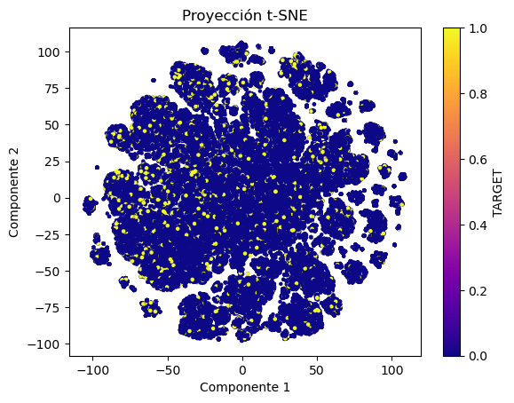

```python
plt.scatter(embedded_data[:, 0], embedded_data[:, 1], c=y_train, cmap='plasma', s=5)
plt.colorbar(label='TARGET')
plt.title('Proyección t-SNE')
plt.xlabel('Componente 1')
plt.ylabel('Componente 2')
plt.show()
```

#### **PCA**

```python
pca_2c = PCA(n_components=2)
pca_2c.fit(X_train_scaled.reset_index(drop=True))
pca_array = pca_2c.transform(X_train_scaled)
```

```python
pca_array
```

```
array([[-1.14580931, -3.51750364],
       [ 0.10088415,  1.1007266 ],
       [ 4.59798001, -2.19994914],
       ...,
       [11.38797935, -3.82695796],
       [-1.16719403,  0.81620095],
       [-0.57682124, -3.19049944]])
```

Vamos a ver que componente pertenece a cada variable, y las vamos a categorizar en función del tamaño de sus autovalores

```python
components = pca_2c.components_
component_names = [f'Component {i+1}' for i in range(2)]
df_components = pd.DataFrame(components.T, columns=component_names, index=X_train_scaled.columns.values)

df_components.style.apply(f.max_coef, features='color:red', axis=1)
# we highlight the biggest eigenvalues in red
```

|  | Component 1 | Component 2 |
| --- | --- | --- |
| SK_ID_CURR | 0.001114 | -0.001621 |
| COMMONAREA_AVG | 0.197389 | 0.023825 |
| NONLIVINGAPARTMENTS_AVG | 0.073670 | 0.005344 |
| FONDKAPREMONT_MODE | -0.161867 | 0.020494 |
| LIVINGAPARTMENTS_AVG | 0.270618 | 0.037783 |
| FLOORSMIN_AVG | 0.175704 | 0.024640 |
| YEARS_BUILD_AVG | 0.114223 | 0.027699 |
| OWN_CAR_AGE | -0.021034 | 0.021304 |
| LANDAREA_AVG | 0.173141 | 0.021291 |
| BASEMENTAREA_AVG | 0.226410 | 0.029420 |
| EXT_SOURCE_1 | 0.043306 | -0.121842 |
| NONLIVINGAREA_AVG | 0.151231 | 0.013211 |
| ELEVATORS_AVG | 0.316627 | 0.028803 |
| WALLSMATERIAL_MODE | -0.214224 | 0.022007 |
| APARTMENTS_AVG | 0.311174 | 0.039856 |
| ENTRANCES_AVG | 0.193878 | 0.022025 |
| LIVINGAREA_AVG | 0.315678 | 0.038808 |
| HOUSETYPE_MODE_Sin valor | -0.177343 | 0.031056 |
| HOUSETYPE_MODE_block of flats | 0.179712 | -0.031184 |
| HOUSETYPE_MODE_specific housing | -0.003773 | 0.003388 |
| HOUSETYPE_MODE_terraced house | -0.014291 | -0.002757 |
| FLOORSMAX_AVG | 0.266631 | 0.025604 |
| YEARS_BEGINEXPLUATATION_AVG | 0.024748 | 0.003886 |
| TOTALAREA_MODE | 0.316313 | 0.039130 |
| EMERGENCYSTATE_MODE | -0.024738 | -0.005559 |
| OCCUPATION_TYPE | -0.043741 | 0.185906 |
| EXT_SOURCE_3 | 0.011184 | -0.073251 |
| ORGANIZATION_TYPE | -0.015483 | 0.296411 |
| AMT_REQ_CREDIT_BUREAU_HOUR | 0.001786 | 0.000009 |
| AMT_REQ_CREDIT_BUREAU_DAY | 0.003943 | -0.000024 |

[output cut: 66 more lines]

Este análisis es útil para entender cómo se organizan las variables dentro de los datos, pero a pesar de la agrupación, se debe tener en cuenta que PCA no siempre es la mejor opción para todos los modelos. Como hemos observado en el análisis, algunas de estas variables no presentan una correlación significativa entre ellas, lo que genera una varianza explicada relativamente baja al usar pocos componentes. Por lo tanto, aunque la reducción de dimensionalidad puede ayudar a entender los datos, en este caso no sería la mejor herramienta para simplificar el modelo sin perder información relevante.

```python
df_pca_array = pd.DataFrame(data=pca_array, columns=['PC 1', 'PC 2'])
df_pca2c = pd.concat([df_pca_array, y_train.reset_index(drop=True)], axis = 1)
```

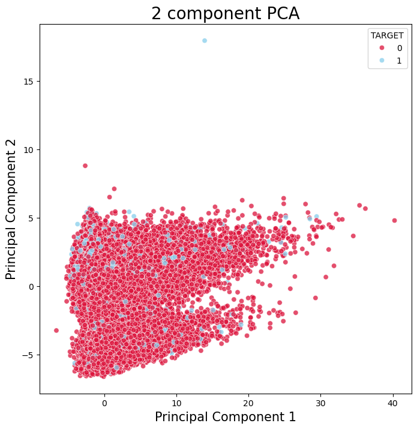

```python
fig, ax = plt.subplots(figsize=(8,8))
sns.scatterplot(data=df_pca2c, x='PC 1', y='PC 2', hue='TARGET', alpha=0.75, palette=['crimson','skyblue'])
ax.set_xlabel('Principal Component 1', fontsize = 15)
ax.set_ylabel('Principal Component 2', fontsize = 15)
ax.set_title('2 component PCA', fontsize = 20)
plt.show()
```

La gráfica no aporta ninguna información clara, por lo que ya nos podemos hacer una idea de que sólo dos componentes no explican un porcentaje suficientemente alto de la varianza. Vamos a comprobar la explicabilidad de la varianza:

```python
#two component variance
pca_2c.explained_variance_ratio_.sum()
```

```
0.13557771777255923
```

La varianza explicada con dos componentes es sólo del 13.56%. Vamos a estudiar cómo se comporta con más componentes.

```python
pca = PCA() # we don't specify the number of components to visualize the explained variance

pca.fit(X_train_scaled)
X_train_pca = pca.transform(X_train_scaled)
X_test_pca = pca.transform(X_test_scaled)
```

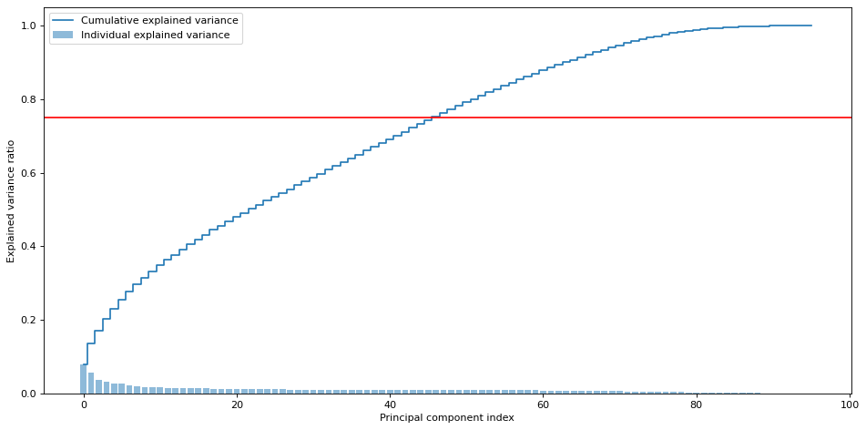

```python
exp_var_pca = pca.explained_variance_ratio_

cum_sum_eigenvalues = np.cumsum(exp_var_pca)

threshold = 0.75
plt.figure(figsize=(12, 6), dpi=80)
plt.bar(range(0,len(exp_var_pca)), exp_var_pca, alpha=0.5, align='center', label='Individual explained variance')
plt.step(range(0,len(cum_sum_eigenvalues)), cum_sum_eigenvalues, where='mid',label='Cumulative explained variance')
plt.axhline(y=threshold, color='r', linestyle='-')

plt.ylabel('Explained variance ratio')
plt.xlabel('Principal component index')
plt.legend(loc='best')
plt.tight_layout()
plt.show()
```

```
Varianza explicada por 2 components: 0.13478
Varianza explicada por 3 components: 0.16985
Varianza explicada por 4 components: 0.19765
Varianza explicada por 5 components: 0.22436
Varianza explicada por 6 components: 0.25041
Varianza explicada por 7 components: 0.27119
Varianza explicada por 8 components: 0.29106
Varianza explicada por 9 components: 0.30902
Varianza explicada por 10 components: 0.32638
Varianza explicada por 11 components: 0.34232
Varianza explicada por 12 components: 0.35711
Varianza explicada por 13 components: 0.37158
Varianza explicada por 14 components: 0.38560
Varianza explicada por 15 components: 0.39960
Varianza explicada por 16 components: 0.41316
Varianza explicada por 17 components: 0.42666
Varianza explicada por 18 components: 0.43943
Varianza explicada por 19 components: 0.45176
Varianza explicada por 20 components: 0.46346
Varianza explicada por 21 components: 0.47487
Varianza explicada por 22 components: 0.48623
Varianza explicada por 23 components: 0.49752
Varianza explicada por 24 components: 0.50861
Varianza explicada por 25 components: 0.51955
Varianza explicada por 26 components: 0.53036
Varianza explicada por 27 components: 0.54114
Varianza explicada por 28 components: 0.55183
Varianza explicada por 29 components: 0.56249
Varianza explicada por 30 components: 0.57312
Varianza explicada por 31 components: 0.58373
Varianza explicada por 32 components: 0.59432
Varianza explicada por 33 components: 0.60490
Varianza explicada por 34 components: 0.61544
Varianza explicada por 35 components: 0.62597
Varianza explicada por 36 components: 0.63649
Varianza explicada por 37 components: 0.64699
Varianza explicada por 38 components: 0.65747
Varianza explicada por 39 components: 0.66792
Varianza explicada por 40 components: 0.67837
Varianza explicada por 41 components: 0.68879
```

[output cut: 39 more lines]

```
Varianza explicada por 81 components: 0.98881
Varianza explicada por 82 components: 0.99091
Varianza explicada por 83 components: 0.99234
Varianza explicada por 84 components: 0.99362
Varianza explicada por 85 components: 0.99473
Varianza explicada por 86 components: 0.99575
Varianza explicada por 87 components: 0.99672
Varianza explicada por 88 components: 0.99762
Varianza explicada por 89 components: 0.99844
Varianza explicada por 90 components: 0.99896
Varianza explicada por 91 components: 0.99946
Varianza explicada por 92 components: 0.99986
Varianza explicada por 93 components: 0.99998
Varianza explicada por 94 components: 1.00000
Varianza explicada por 95 components: 1.00000
```

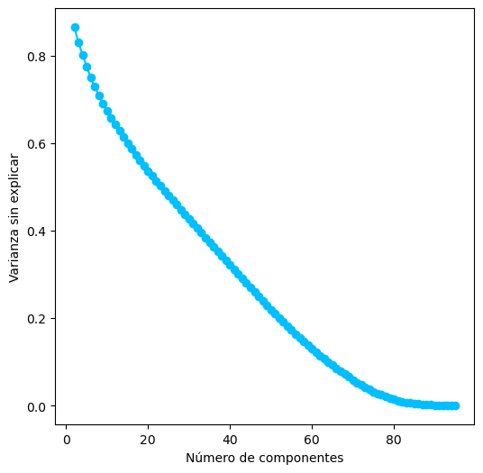

```python
ve_list = []
vne_list = []
n_comp = range(2,96)

for n in n_comp:
    pca = PCA(n_components=n)
    pca.fit(X_train_scaled.reset_index(drop=True))
    ve = pca.explained_variance_ratio_.sum()
    ve_list.append(ve)
    vne = 1-ve
    vne_list.append(vne)
    print(f'Varianza explicada por {n} components: {ve:.5f}')

plt.figure(figsize=(6, 6))
plt.plot(n_comp, vne_list, '-o', color='deepskyblue')
plt.xlabel(f'Número de componentes')
plt.ylabel('Varianza sin explicar')
plt.show()
```

A partir de 64 componentes, conseguimos explicar el 90% de la varianza, lo que es bastante significativo, y quitando dos componentes (quedándonos con 94) se explicaría el 100%, lo que nos está diciendo que al menos hay dos variables completamente irrelevantes, además de varias que están cerca de serlo.

```python
dump(pca_2c, '../models/pca_2componentes.joblib')
```

```
['../models/pca_2componentes.joblib']
```

#### **K-means**

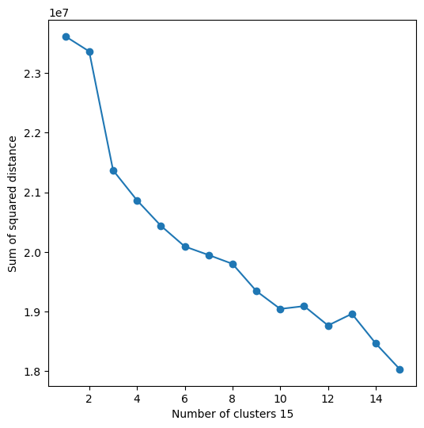

```python
f.k_means_search(X_train_scaled, 15)
```

Vamos a analizar la calidad de los clusters para ver si sería una buena idea reducir dimensionalidad usando KMeans como un método de preprocesamiento.

```python
for k in range(2, 8):  # Probar diferentes números de clusters
    kmeans = KMeans(n_clusters=k, random_state=seed)
    kmeans.fit(X_train_scaled)
    labels = kmeans.labels_

    silhouette_avg = silhouette_score(X_train_scaled, labels)
    calinski_harabasz = calinski_harabasz_score(X_train_scaled, labels)

    print(f"k = {k} -> Silueta: {silhouette_avg:.2f}, Calinski-Harabasz: {calinski_harabasz:.2f}")
```

```
k = 2 -> Silueta: 0.21, Calinski-Harabasz: 13533.86
k = 3 -> Silueta: 0.06, Calinski-Harabasz: 12933.81
k = 4 -> Silueta: 0.06, Calinski-Harabasz: 11343.10
k = 5 -> Silueta: 0.07, Calinski-Harabasz: 9279.47
k = 6 -> Silueta: 0.07, Calinski-Harabasz: 8111.06
k = 7 -> Silueta: 0.03, Calinski-Harabasz: 7087.89
```

**Interpretación de los coeficientes de la silueta**:

- [0.7, 1]: Clusters muy compactos.
- [0.5, 0.7]: Buena estructura de clustering.
- [0.25, 0.5]: Los clusters se solapan moderadamente.
- < 0.25: Los clusters no bien definidos.

**Índice de Calinski-Harabasz**:

- Valores más altos significan que los clusters son más compactos y están mejor separados.

## **Feature Selection**

#### Árbol de decisión

Vamos a tirar un modelo de árbol, al que añadimos una variable aleatoria, para ver que features son más importantes

```python
X_train_f['random_feature'] = np.random.rand(len(X_train_f))
X_test_f['random_feature'] = np.random.rand(len(X_test_f))
```

```python
clf = RandomForestClassifier(n_estimators=300
                             ,criterion='gini'
                             ,max_depth=10
                             ,random_state=seed)
clf.fit(X_train_f, y_train)
```

```
RandomForestClassifier(max_depth=10, n_estimators=300, random_state=12345)
```

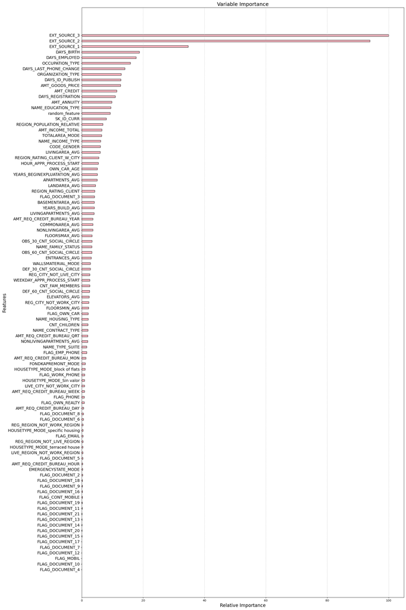

```python
# Hacer las importancias relativas al máximo
feature_importance = clf.feature_importances_
feature_importance = 100.0 * (feature_importance / feature_importance.max())

# Ordenar los índices según las importancias
sorted_idx = np.argsort(feature_importance)

# Crear posiciones con mayor separación
bar_width = 0.5  # Altura de las barras
pos = np.arange(sorted_idx.shape[0]) * 1.5  # Incrementa el espaciado entre barras

# Configuración del gráfico
plt.figure(figsize=(20, 30))  # Tamaño grande para evitar solapamientos
plt.barh(pos, feature_importance[sorted_idx], align='center', height=bar_width, color='lightpink', edgecolor='black')
plt.yticks(pos, X_train_f.keys()[sorted_idx], fontsize=14)  # Tamaño más grande para las etiquetas


# Configuración de los ejes y título
plt.xlabel('Relative Importance', fontsize=16)
plt.ylabel('Features', fontsize=16)
plt.title('Variable Importance', fontsize=18)

# Añadir líneas de referencia opcionales
plt.grid(axis='x', linestyle='--', alpha=0.7)

# Ajustar automáticamente los espacios
plt.tight_layout()
plt.show()
```

```python
# Eliminar la columna 'random_feature' de ambos conjuntos de datos
X_train_f = X_train_f.drop(columns=['random_feature'], errors='ignore')
X_test_f = X_test_f.drop(columns=['random_feature'], errors='ignore')

# Re-entrenar el modelo con los datos sin la columna 'random_feature'
clf.fit(X_train_f, y_train)
```

```
RandomForestClassifier(max_depth=10, n_estimators=300, random_state=12345)
```

Al eliminar la columna ‘random_feature’ de los datos, reentrenamos el modelo y observamos cómo este le daba mucha importancia a dicha columna. Esto nos hace pensar que variables con características similares o con poca relevancia podrían ser consideradas como ruido o irrelevantes por el modelo.

### **Regresiones con regularización logística**

Para esta sección, vamos a eliminar una de las variables correspondiente a una de las categorías de HOUSETYPE_MODE generadas en el One-Hot Encoding, para evitar duplicados de información.

```python
X_train_scaled = X_train_scaled.drop('HOUSETYPE_MODE_Sin valor', axis=1)
```

#### Regularización Ridge

```python
sel_ridge = SelectFromModel(LogisticRegression(C=1, penalty='l2'), threshold = 0.05)
sel_ridge.fit(X_train_scaled, y_train)
```

```
SelectFromModel(estimator=LogisticRegression(C=1), threshold=0.05)
```

[figure not shown]

```python
# Coeficientes del modelo
# ==============================================================================

f.reg_coefs(X_train_scaled, sel_ridge)
```

```python
sel_ridge.get_support()
selected_feat = X_train_scaled.columns[sel_ridge.get_support()]
selected_feat
```

```
Index(['EXT_SOURCE_1', 'OCCUPATION_TYPE', 'EXT_SOURCE_3', 'ORGANIZATION_TYPE', 'AMT_REQ_CREDIT_BUREAU_QRT', 'DEF_30_CNT_SOCIAL_CIRCLE', 'EXT_SOURCE_2', 'AMT_GOODS_PRICE', 'AMT_ANNUITY', 'CODE_GENDER', 'DAYS_LAST_PHONE_CHANGE', 'FLAG_DOCUMENT_10', 'FLAG_DOCUMENT_3', 'FLAG_DOCUMENT_4', 'FLAG_DOCUMENT_…
```

```python
print('total features: {}'.format((X_train_scaled.shape[1])))
print('selected features: {}'.format(len(selected_feat)))
```

```
total features: 95
selected features: 26
```

#### Regularización Lasso

```python
sel_lasso = SelectFromModel(LogisticRegression(C=1, penalty='l1',
                                          solver='liblinear'), threshold = 0.05)
sel_lasso.fit(X_train_scaled, y_train)
```

```
SelectFromModel(estimator=LogisticRegression(C=1, penalty='l1',
                                             solver='liblinear'),
                threshold=0.05)
```

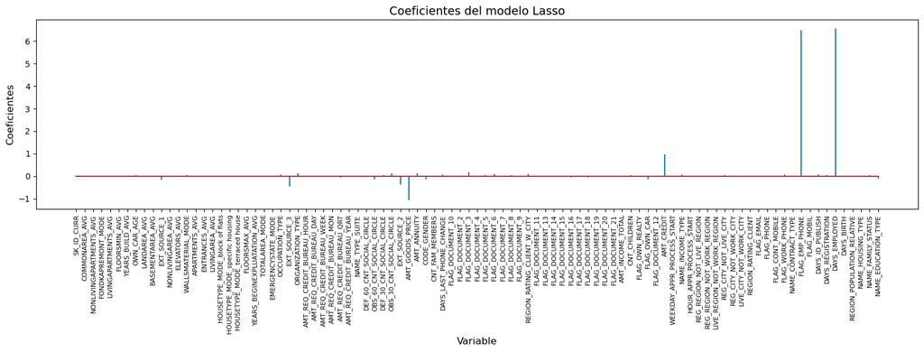

```python
# Coeficientes del modelo
# ==============================================================================

f.reg_coefs(X_train_scaled, sel_lasso)
```

```python
sel_lasso.get_support()
selected_feat_lasso = X_train_scaled.columns[sel_lasso.get_support()]
selected_feat_lasso
```

```
Index(['EXT_SOURCE_1', 'OCCUPATION_TYPE', 'EXT_SOURCE_3', 'ORGANIZATION_TYPE', 'AMT_REQ_CREDIT_BUREAU_QRT', 'OBS_60_CNT_SOCIAL_CIRCLE', 'DEF_30_CNT_SOCIAL_CIRCLE', 'OBS_30_CNT_SOCIAL_CIRCLE', 'EXT_SOURCE_2', 'AMT_GOODS_PRICE', 'AMT_ANNUITY', 'CODE_GENDER', 'DAYS_LAST_PHONE_CHANGE', 'FLAG_DOCUMENT_3'…
```

```python
print('total features: {}'.format((X_train_scaled.shape[1])))
print('selected features: {}'.format(len(selected_feat_lasso)))
```

```
total features: 95
selected features: 27
```

#### Regularización ElasticNet

Vamos a probar también la regularización, que combina las regularizaciones L1 y L2 que hemos hecho anteriormente.

```python
sel_elasticnet = SelectFromModel(LogisticRegression(C=1, penalty='elasticnet', l1_ratio=0.5, solver='saga'), threshold = 0.05)
sel_elasticnet.fit(X_train_scaled, y_train)
```

```
SelectFromModel(estimator=LogisticRegression(C=1, l1_ratio=0.5,
                                             penalty='elasticnet',
                                             solver='saga'),
                threshold=0.05)
```

[figure not shown]

```python
# Coeficientes del modelo
# ==============================================================================

f.reg_coefs(X_train_scaled, sel_elasticnet)
```

```python
sel_elasticnet.get_support()
selected_feat_elasticnet = X_train_scaled.columns[sel_elasticnet.get_support()]
selected_feat_elasticnet
```

```
Index(['EXT_SOURCE_1', 'OCCUPATION_TYPE', 'EXT_SOURCE_3', 'ORGANIZATION_TYPE', 'AMT_REQ_CREDIT_BUREAU_QRT', 'DEF_30_CNT_SOCIAL_CIRCLE', 'EXT_SOURCE_2', 'AMT_GOODS_PRICE', 'AMT_ANNUITY', 'CODE_GENDER', 'DAYS_LAST_PHONE_CHANGE', 'FLAG_DOCUMENT_3', 'REGION_RATING_CLIENT_W_CITY', 'FLAG_DOCUMENT_18', 'FL…
```

```python
print('total features: {}'.format((X_train_scaled.shape[1])))
print('selected features: {}'.format(len(selected_feat_elasticnet)))
```

```
total features: 95
selected features: 22
```

#### Boruta

```python
# sampling in proportion to y labels
rf = RandomForestClassifier(n_jobs=-1, max_depth=10)  # num leaves

# define Boruta feature selection method
np.int = np.int32
np.float = np.float64
np.bool = np.bool_

feat_selector = BorutaPy(rf, n_estimators='auto', verbose=2, random_state=seed)

# find all relevant features - 5 features should be selected
feat_selector.fit(X_train_f.values, y_train.values)

# check selected features - first 5 features are selected
feat_selector.support_

# check ranking of features
feat_selector.ranking_
```

[output not shown]

[output cut: 41 more lines]

```
Confirmed: 	15
Tentative: 	1
Rejected: 	80
Iteration: 	22 / 100
Confirmed: 	15
Tentative: 	0
Rejected: 	81


BorutaPy finished running.

Iteration: 	23 / 100
Confirmed: 	15
Tentative: 	0
Rejected: 	81
```

```
array([ 4, 27, 43, 47, 18, 37, 19, 10, 17, 20,  1, 25, 33, 23, 13, 31,  9,
       45, 41, 59, 62, 22, 14,  7, 61,  1,  1,  1, 62, 52, 50, 46, 42, 23,
       44, 33, 29, 26, 29,  1,  1,  1,  1, 33,  1, 80, 59, 11, 80, 65, 54,
       78, 55, 69,  3, 70, 75, 74, 76, 67, 77, 68, 70, 72, 73,  8, 40, 53,
       38, 80,  1, 39,  2, 12, 58, 56, 64, 21, 15, 47,  4, 57, 51, 66, 49,
       35, 29, 80,  1,  1,  1,  1,  6, 36, 16,  1])
```

```python
selected_feat_boruta = X_train_f.columns[feat_selector.support_]
selected_feat_boruta
```

```
Index(['EXT_SOURCE_1', 'OCCUPATION_TYPE', 'EXT_SOURCE_3', 'ORGANIZATION_TYPE', 'EXT_SOURCE_2', 'AMT_GOODS_PRICE', 'AMT_ANNUITY', 'CODE_GENDER', 'DAYS_LAST_PHONE_CHANGE', 'AMT_CREDIT', 'DAYS_ID_PUBLISH', 'DAYS_REGISTRATION', 'DAYS_EMPLOYED', 'DAYS_BIRTH', 'NAME_EDUCATION_TYPE'], dtype='object')
```

### **Selección final de las variables**

En el análisis de selección de variables, decidimos no considerar los resultados del modelo **Random Forest**, ya que al añadir una variable aleatoria, el modelo le otorgaba demasiada importancia. Esto nos llevó a concluir que los resultados de **Random Forest** no eran adecuados para la selección de las variables en nuestro análisis.

En cuanto al modelo **Boruta**, decidimos tomar todas las variables que este seleccionó, ya que **Boruta** evalúa la relevancia de cada característica en comparación con variables aleatorias, lo cual nos ayuda a identificar las variables más relevantes para el modelo. Además, **Boruta** no tiene restricciones matemáticas como la linealidad, lo que lo hace más flexible que otros métodos.

Con respecto a las regresiones logísticas, realizamos un análisis exhaustivo de las variables seleccionadas por los modelos **Ridge**, **Lasso y ElasticNet**. Después de este análisis, decidimos quedarnos principalmente con las variables que fueron seleccionadas por todos los modelos. Para aquellas variables que solo aparecieron en uno o dos modelos, tomamos las siguientes decisiones:

1. **Modelo ElasticNet**: Decidimos conservar todas las variables seleccionadas por **ElasticNet**, ya que combina las regularizaciones de **Ridge** y **Lasso**. Este enfoque, que selecciona un número reducido de variables, lo consideramos más fiable. Las variables seleccionadas por **ElasticNet** son: **name_contract_type**, **name_family_status**, **amt_req_credit_bureau_qrt**, **def_30_cnt_social_circle**, **region_rating_client_w_city**, **flag_document_3**, **flag_document_18**, **flag_own_car**.
2. **Modelos Ridge y Lasso**: Conservamos las variables que fueron seleccionadas por ambos modelos, aunque no estén presentes en **ElasticNet**, porque creemos que si estas variables pasaron ambos filtros, tienen una buena capacidad predictiva. Las variables seleccionadas son: **flag_document_6**, **flag_document_8** y **reg_city_not_live_city**.

De esta forma, hemos creado una selección robusta y confiable de las variables para utilizar en nuestro modelo, basada en la evaluación conjunta de los tres métodos.

```python
selected_feat_elasticnet=['EXT_SOURCE_1', 'OCCUPATION_TYPE', 'EXT_SOURCE_3', 'ORGANIZATION_TYPE', 'AMT_REQ_CREDIT_BUREAU_QRT', 'DEF_30_CNT_SOCIAL_CIRCLE', 'EXT_SOURCE_2', 'AMT_GOODS_PRICE', 'AMT_ANNUITY', 'CODE_GENDER', 'DAYS_LAST_PHONE_CHANGE', 'FLAG_DOCUMENT_3', 'REGION_RATING_CLIENT_W_CITY', 'FLAG_DOCUMENT_18', 'FLAG_OWN_CAR', 'AMT_CREDIT', 'NAME_INCOME_TYPE', 'NAME_CONTRACT_TYPE', 'DAYS_ID_PUBLISH', 'DAYS_EMPLOYED', 'NAME_FAMILY_STATUS', 'NAME_EDUCATION_TYPE']
```

```python
selected_feat_boruta = ['EXT_SOURCE_1', 'OCCUPATION_TYPE', 'EXT_SOURCE_3', 'ORGANIZATION_TYPE', 'EXT_SOURCE_2', 'AMT_GOODS_PRICE', 'AMT_ANNUITY', 'CODE_GENDER', 'DAYS_LAST_PHONE_CHANGE', 'AMT_CREDIT', 'DAYS_ID_PUBLISH', 'DAYS_REGISTRATION', 'DAYS_EMPLOYED', 'DAYS_BIRTH', 'NAME_EDUCATION_TYPE']
```

```python
selected_feat_man = list(set(selected_feat_boruta + list(selected_feat_elasticnet)))
selected_feat_man.extend(['FLAG_DOCUMENT_6', 'FLAG_DOCUMENT_8', 'REG_CITY_NOT_LIVE_CITY'])
```

```python
len(selected_feat_man)
```

```
27
```

```python
X_train_t = X_train_f[selected_feat_man]
X_test_t = X_test_f[selected_feat_man]
```

#### Probamos de nuevo el RandomForest con las variables seleccionadas

```python
clf_2= RandomForestClassifier(n_estimators=300
                             ,criterion='gini'
                             ,max_depth=5
                             ,random_state=seed)
clf_2.fit(X_train_t, y_train)
```

```
RandomForestClassifier(max_depth=5, n_estimators=300, random_state=12345)
```

```python
# Realizar predicciones
pred_test = clf_2.predict_proba(X_test_t)
pred_train = clf_2.predict_proba(X_train_t)
```

#### Curva ROC

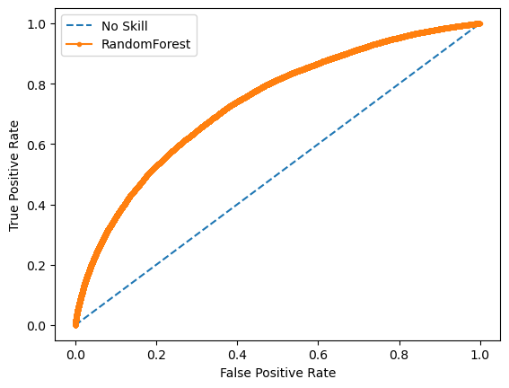

```python
# keep probabilities for the positive outcome only
yhat_train = pred_train[:, 1]
# calculate roc curves
fpr, tpr, thresholds = roc_curve(y_train, yhat_train)
# plot the roc curve for the model
plt.plot([0,1], [0,1], linestyle='--', label='No Skill')
plt.plot(fpr, tpr, marker='.', label='RandomForest')
# axis labels
plt.xlabel('False Positive Rate')
plt.ylabel('True Positive Rate')
plt.legend()
# show the plot
plt.show()
```

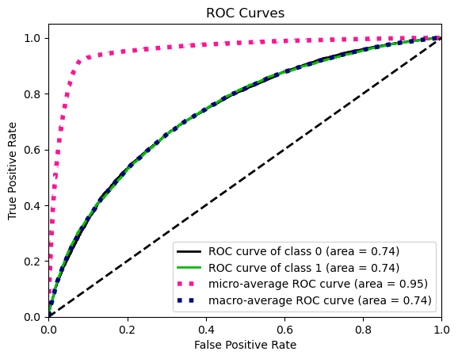

```python
skplt.metrics.plot_roc(y_test, clf_2.predict_proba(X_test_t))
plt.show()
```

```python
# calculate AUC
auc_curve = roc_auc_score(y_train, yhat_train)
print('AUC: %.3f' % auc_curve)
```

```
AUC: 0.736
```

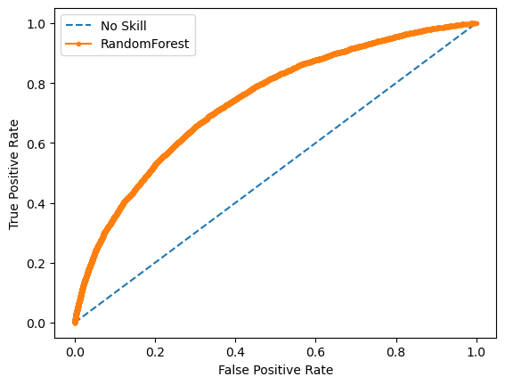

```python
# keep probabilities for the positive outcome only
yhat = pred_test[:, 1]
# calculate roc curves
fpr, tpr, thresholds = roc_curve(y_test, yhat)
# plot the roc curve for the model
plt.plot([0,1], [0,1], linestyle='--', label='No Skill')
plt.plot(fpr, tpr, marker='.', label='RandomForest')
# axis labels
plt.xlabel('False Positive Rate')
plt.ylabel('True Positive Rate')
plt.legend()
# show the plot
plt.show()
```

```python
# calculate AUC
auc_curve = roc_auc_score(y_test, yhat)
print('AUC: %.3f' % auc_curve)
```

```
AUC: 0.739
```

#### Guardamos los datos

```python
data_train_t = X_train_t.copy()
data_train_t['TARGET'] = pd_data_train['TARGET']
data_test_t = X_test_t.copy()
data_test_t['TARGET'] = pd_data_test['TARGET']
```

```python
data_train_t.to_csv('../data/data_train_processed.csv', index=False)
data_test_t.to_csv('../data/data_test_processed.csv', index=False)
```

### **Creación del pipeline**

Esta parte del notebook no está completa, ya que ha surgido un error que antes no saltaba, y no hemos sido capaces de solucionarlo. El pipeline de los features si que funciona, pero el de preprocessing no, así que dejamos las componentes que lo forman como texto de markdown. El código del pipeline como tal no está bien porque hemos hecho varias pruebas para solucionarlo, pero creemos que es interesante dejar el transformer customizado que hemos diseñado para la variable education type.

```python
def feature_selection(df, add=[]):

    # Columnas a seleccionar
    selected_columns = ['FLAG_OWN_CAR', 'FLAG_DOCUMENT_3', 'DAYS_REGISTRATION',
                        'DAYS_LAST_PHONE_CHANGE', 'DAYS_ID_PUBLISH', 'NAME_CONTRACT_TYPE',
                        'EXT_SOURCE_3', 'AMT_GOODS_PRICE', 'OCCUPATION_TYPE', 'DAYS_EMPLOYED', 'DAYS_BIRTH',
                        'EXT_SOURCE_1', 'AMT_REQ_CREDIT_BUREAU_QRT', 'AMT_CREDIT', 'DEF_30_CNT_SOCIAL_CIRCLE',
                        'ORGANIZATION_TYPE', 'NAME_FAMILY_STATUS', 'REGION_RATING_CLIENT_W_CITY', 'EXT_SOURCE_2',
                        'AMT_ANNUITY', 'NAME_INCOME_TYPE', 'CODE_GENDER', 'NAME_EDUCATION_TYPE', 'FLAG_DOCUMENT_18',
                        'FLAG_DOCUMENT_6', 'FLAG_DOCUMENT_8', 'REG_CITY_NOT_LIVE_CITY']

    # Si se añade alguna columna adicional, la agregamos a la lista de selección
    if add:
        selected_columns += add

    df_new = df[selected_columns]

    return df_new
```